# Spectral Graph Clustering using `gmmase`

JHU Team

2017-09-07

Given a (possibly directed) (possibly weighted) graph $G=(V,E)$, the `gmmase` package does

1. do a *pass-to-rank* for a weighted graph (`PTR`, no-op for an unweighted graph),
2. do a *graph spectral embedding* (`ASE` or `LSE`[^1]) with a *diagonal augmentation*,
3. do a *dimension reduction* (`ZG`[^2]) and merge left and right vectors (no-op for an undirected graph),
4. cluster vertices (`GMM`[^3] or `Kmeans`).

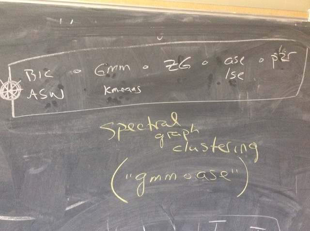

# Connectome Data

This vignette demo uses a connectome data[^4] with 123 vertices and 2740 edges.

```r
library(gmmase)
suppressPackageStartupMessages(library(igraph))

data("akira")
summary(akira)
```

```
# IGRAPH 1770d3c DNW- 123 2740 --
# + attr: name (v/c), weight (e/n)
```

```r
knitr::kable(as.matrix(akira[])[1:10,1:10], digits=2)
```

|  | CN1_FB5 | CN2 | CN3 | CN4_FB12 | CN5_FB13 | CN6_FB16 | CN7 | CN8_FB21 | CN9 | CN10 |
| --- | --- | --- | --- | --- | --- | --- | --- | --- | --- | --- |
| CN1_FB5 | 0.00 | 0.00 | 0.00 | 0.00 | 0.00 | 0.00 | 0.19 | 0 | 0 | 0 |
| CN2 | 0.00 | 0.00 | 0.28 | 0.21 | 0.00 | 0.00 | 0.00 | 0 | 0 | 0 |
| CN3 | 0.00 | 0.25 | 0.00 | 0.10 | 0.23 | 0.10 | 0.00 | 0 | 0 | 0 |
| CN4_FB12 | 0.00 | 0.00 | 0.00 | 0.00 | 0.00 | 0.00 | 0.00 | 0 | 0 | 0 |
| CN5_FB13 | 0.00 | 0.00 | 0.00 | 0.00 | 0.00 | 0.31 | 0.00 | 0 | 0 | 0 |
| CN6_FB16 | 0.00 | 0.00 | 0.00 | 0.00 | 0.80 | 0.00 | 0.00 | 0 | 0 | 0 |
| CN7 | 0.00 | 0.00 | 0.00 | 0.00 | 0.00 | 0.00 | 0.00 | 0 | 0 | 0 |
| CN8_FB21 | 0.00 | 0.06 | 0.14 | 0.00 | 0.00 | 0.10 | 0.00 | 0 | 0 | 0 |
| CN9 | 0.00 | 0.00 | 0.00 | 0.00 | 0.00 | 0.00 | 0.00 | 0 | 0 | 0 |
| CN10 | 0.13 | 0.81 | 0.00 | 0.00 | 1.48 | 2.28 | 0.00 | 0 | 0 | 0 |

```r
# take induced subgraph using only CN neurons
cn <- grep("CN", V(akira)$name)
g.cn <- induced_subgraph(akira, cn)
```

## `gmmase`

```r
out <- gmmase(g.cn, dmax = 20, embed = "ASE", clustering = "GMM", verbose=FALSE)
```

```
# 1. Finding an lcc...
# IGRAPH f038699 DNW- 43 515 --
# + attr: name (v/c), weight (e/n)
# 2. Passing-to-rank...
# IGRAPH f038699 DNW- 43 515 --
# + attr: name (v/c), weight (e/n)
# 3. Embedding the graph into dmax = 20...
# 4. Finding an elbow (dimension reduction)...
```

```
# , use dhat =  2
# 5. Clustering vertices..., Khat =  4
```

```
# ----------------------------------------------------
# Gaussian finite mixture model fitted by EM algorithm
# ----------------------------------------------------
#
# Mclust EEV (ellipsoidal, equal volume and shape) model with 4 components:
#
#  log.likelihood  n df       BIC       ICL
#        74.86953 43 47 -27.03735 -27.88816
#
# Clustering table:
#  1  2  3  4
# 11  8  9 15
```

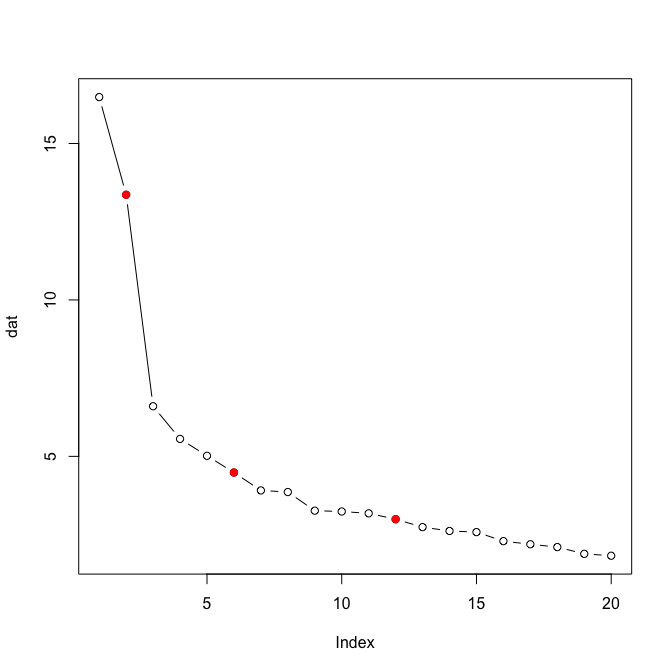

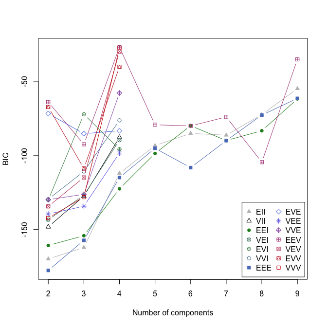

Now, we are plotting a paired scatter plot colored by the clustering labels.

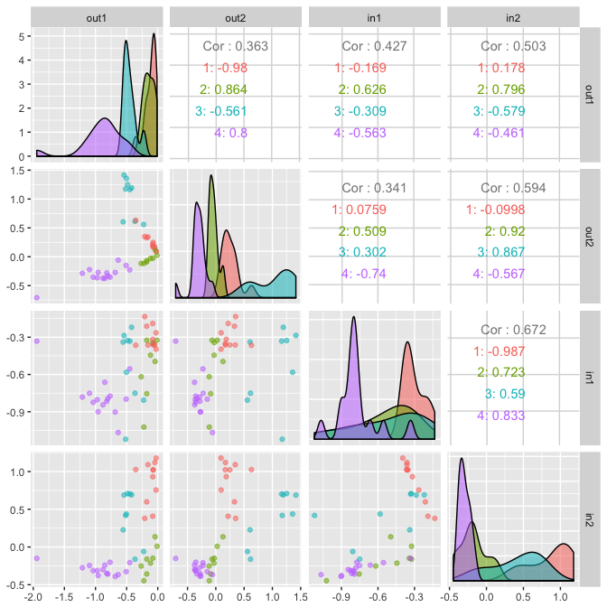

```r
g <- out$g
mc <- out$mc
Xhat <- mc$data
dhat <- ncol(Xhat)/2
Khat <- mc$G
colnames(Xhat) <- paste0(rep(c("out","in"),each=2), 1:2)
class <- mc$classification
df <- data.frame(Xhat, cluster=factor(class))

library(ggplot2)
library(GGally)
ggpairs(df, columns=1:ncol(Xhat), mapping=aes(color=cluster, alpha=0.5))
```

## co-clustering

The data provider informed us from their beahvioral experiments that following neurons should be clustered onto their own groups.

- `CN4`, `CN12` `CN18`, and `CN41`,
- `CN19`,
- `CN40`.

```r
v1 <- c(4,12,18,41)
v2 <- 40
v3 <- 19
vcc<- c(v1,v2,v3)
df2 <- data.frame(name=V(g)$name, cluster=class)
df2[vcc,]
```

```
#           name cluster
# 4     CN4_FB12       1
# 12   CN12_FB25       1
# 18   CN18_FB30       1
# 41 MBONm1_CN41       1
# 40 MBONc1_CN40       4
# 19        CN19       2
```

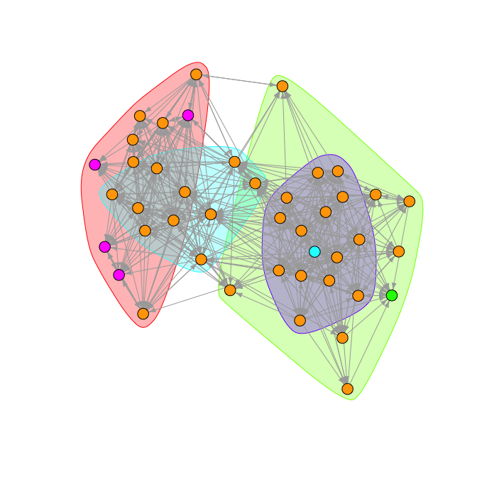

```r
V(g)$color <- "orange"
V(g)$color[v1] <- "magenta"
V(g)$color[v2] <- "cyan"
V(g)$color[v3] <- "green"

plot(g, mark.groups=lapply(1:Khat, function(x) which(class==x)),
     edge.arrow.size=0.5, vertex.label=NA, #vertex.label.cex=0.8,
     vertex.size=7)#, vertex.color=rainbow(3, alpha=.5)[class])
```

This shows that we obtain the desired clustering!

# MNIST Data[^5]

There are 42000 training images of 10 digits (from 0 to 9), and we randomly select 1000 of them for our inference task.

```r
data(smnist)
slab <- smnist$slab
strain <- smnist$strain
(tab <- table(slab))
```

```
## slab
##   0   1   2   3   4   5   6   7   8   9
##  99 105 105 117  97  76  93 102  90 116
```

```r
numTrain <- length(slab)

# Create a 28*28 matrix with pixel color values
res <- sqrt(ncol(strain))
glist <- lapply(1:numTrain, function(x) matrix(unlist(strain[x,]),byrow=T,ncol=res))
```

The following shows five random slections of each digit from the sampled data.

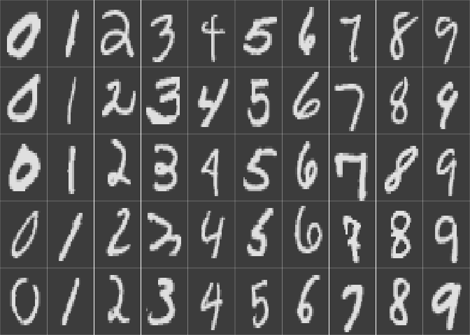

And, followings are averaged images of each digit from the sampled data.

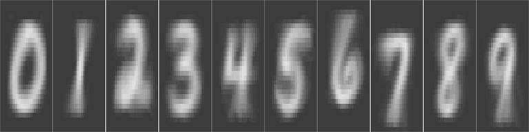

## Graph from Correlation Coefficients

We use Pearson correlation coefficient between two images as a similarity measure.

```r
corrmat <- calcCorr(as.matrix(strain), useCorr=TRUE, recalc=TRUE); range(corrmat)
```

```
# [1] -0.1241095  0.9777664
```

```r
#cor.eps <- median(as.vector(corrmat)); cat("threshold = ", cor.eps, "\n")
cor.eps <- quantile(as.vector(corrmat),0.75); cat("threshold = ", cor.eps, "\n")
```

```
# threshold =  0.380978
```

```r
corrmat[corrmat<cor.eps] <- 0
g <- graph.adjacency(abs(corrmat), mode="undirected", weighted=TRUE); summary(g)
```

```
# IGRAPH c6520f2 U-W- 1000 125000 --
# + attr: weight (e/n)
```

```r
#library(RColorBrewer)
#rf <- colorRampPalette(rev(brewer.pal(11,'Spectral')))
#r <- rf(10)
#V(g)$color <- r[slab+1]
#plot(g, layout=layout.spring,
#     edge.arrow.size=0.5, vertex.label=NA, #vertex.label.cex=0.8,
#     vertex.size=3)#, vertex.color=rainbow(3, alpha=.5)[class])


out1 <- gmmase(g, dmax = 100, embed = "ASE", Kmax = 10, clustering = "GMM", verbose=FALSE)
```

```
# 1. Finding an lcc...
# IGRAPH c290abb U-W- 1000 125000 --
# + attr: weight (e/n)
# 2. Passing-to-rank...
# IGRAPH c290abb U-W- 1000 125000 --
# + attr: weight (e/n)
# 3. Embedding the graph into dmax = 100...
# 4. Finding an elbow (dimension reduction)...
```

```
# , use dhat =  7
# 5. Clustering vertices..., Khat =  10
```

```
# ----------------------------------------------------
# Gaussian finite mixture model fitted by EM algorithm
# ----------------------------------------------------
#
# Mclust VVV (ellipsoidal, varying volume, shape, and orientation) model with 10 components:
#
#  log.likelihood    n  df      BIC     ICL
#        1723.857 1000 359 967.8304 881.793
#
# Clustering table:
#   1   2   3   4   5   6   7   8   9  10
#  92 160  73  89 179 132  62 107  37  69
```

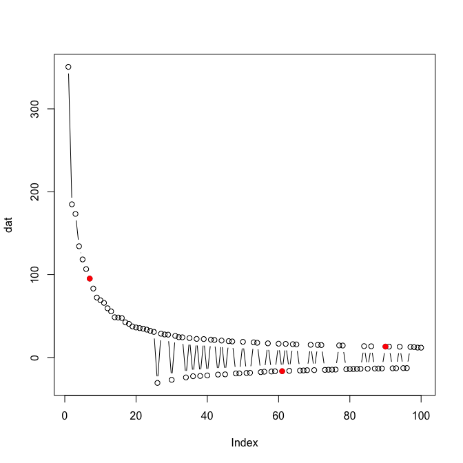

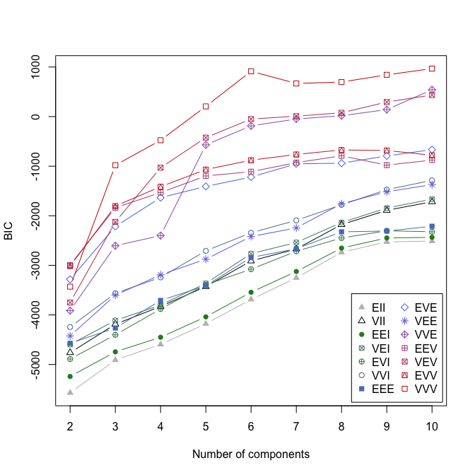

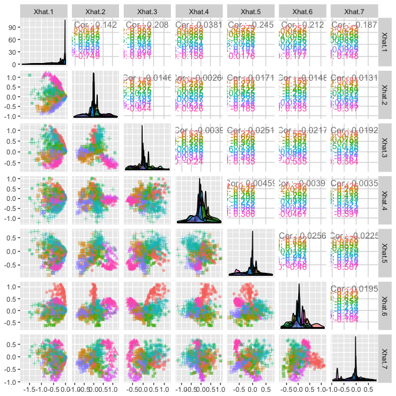

```r
#out1 <- gmmase(g, dmax = 100, embed = "LSE", Kmax = 10, clustering = "GMM", verbose=FALSE)
#out1 <- gmmase(g, dmax = 100, embed = "ASE", Kmax = 10, clustering = "Kmeans", verbose=FALSE)

Xhat1 <- out1$mc$data
Yhat <- out1$Y
df2 <- data.frame(Xhat=Xhat1, lab=as.factor(slab), cluster=as.factor(Yhat))
ggpairs(df2, columns=1:(ncol(df2)-2), mapping=aes(color=cluster, shape=lab, alpha=0.5))
```

Now we plot nine random images of the cluster that contains each digist the most.

|  | 1 | 2 | 3 | 4 | 5 | 6 | 7 | 8 | 9 | 10 |
| --- | --- | --- | --- | --- | --- | --- | --- | --- | --- | --- |
| 0 | 82 | 0 | 0 | 1 | 8 | 6 | 2 | 0 | 0 | 0 |
| 1 | 0 | 0 | 4 | 0 | 1 | 0 | 0 | 0 | 33 | 67 |
| 2 | 1 | 6 | 45 | 23 | 11 | 3 | 15 | 1 | 0 | 0 |
| 3 | 1 | 5 | 1 | 1 | 28 | 76 | 4 | 1 | 0 | 0 |
| 4 | 0 | 45 | 1 | 4 | 3 | 0 | 7 | 37 | 0 | 0 |
| 5 | 5 | 2 | 12 | 2 | 12 | 36 | 3 | 4 | 0 | 0 |
| 6 | 2 | 0 | 3 | 55 | 15 | 0 | 17 | 1 | 0 | 0 |
| 7 | 0 | 50 | 3 | 0 | 13 | 0 | 7 | 25 | 4 | 0 |
| 8 | 0 | 8 | 4 | 0 | 66 | 11 | 0 | 0 | 0 | 1 |
| 9 | 1 | 44 | 0 | 3 | 22 | 0 | 7 | 38 | 0 | 1 |

```
# ARI for Khat = 10  is  0.31
```

```
#  0  1  2  3  4  5  6  7  8  9
#  1 10  3  6  2  6  4  2  5  2
```

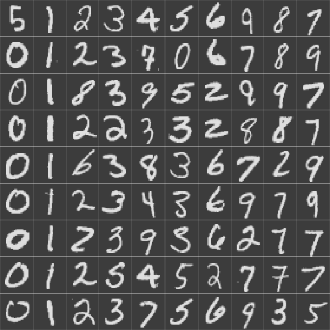

## Graph from $k$-nearest neighbors

From a given point $i$, it is connected to the $k$ other points that are closest to it in the Euclidean space.

```r
D <- as.matrix(dist(strain))
kvec <- 3:9
ariv <- dhatv <- khatv <- rep(0,length(kvec))
for (k in 1:length(kvec)) {
    A <- matrix(0,numTrain,numTrain)
    for (i in 1:numTrain) {
        nn <- order(D[i,])[1:kvec[k]]
        A[i,nn] <- A[nn,i] <- 1
    }
    diag(A) <- 0

    g.knn <- graph.adjacency(A, mode="undirected"); summary(g.knn)
    out2 <- gmmase(g.knn, dmax = 20, embed = "ASE", Kmax = 10, clustering = "GMM",
                   verbose=FALSE, doplot=FALSE)
    dhatv[k] <- out2$elb
    Yhat2 <- out2$Y
    khatv[k] <- max(Yhat2)
    ariv[k] <- adjustedRandIndex(slab, Yhat2)
    cat("k = ", kvec[k], ", dhat = ", dhatv[k], ", Khat = ", khatv[k], ", ari = ", ariv[k], "\n")
}
```

| k | dhat | khat | ari |
| --- | --- | --- | --- |
| 3 | 17 | 10 | 0.24 |
| 4 | 8 | 10 | 0.27 |
| 5 | 7 | 10 | 0.27 |
| 6 | 10 | 10 | 0.36 |
| 7 | 9 | 10 | 0.40 |
| 8 | 9 | 10 | 0.38 |
| 9 | 10 | 10 | 0.42 |

Let’s see the example run of $argmax_k ARI = $ 9.

```
# IGRAPH e0a0df2 U--- 1000 5797 --
```

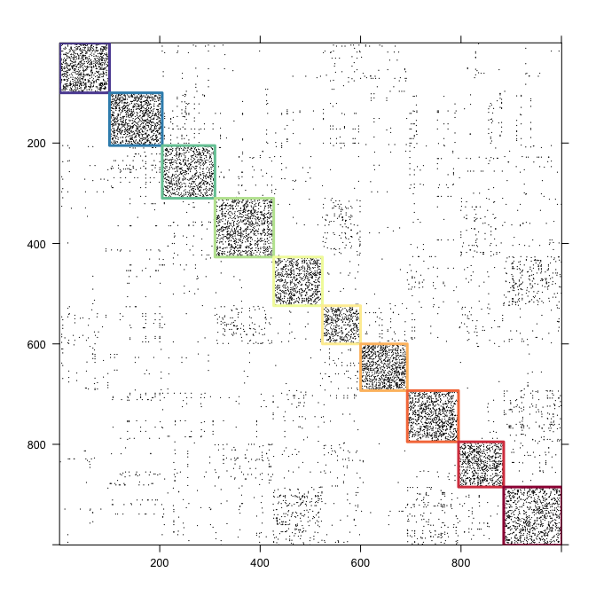

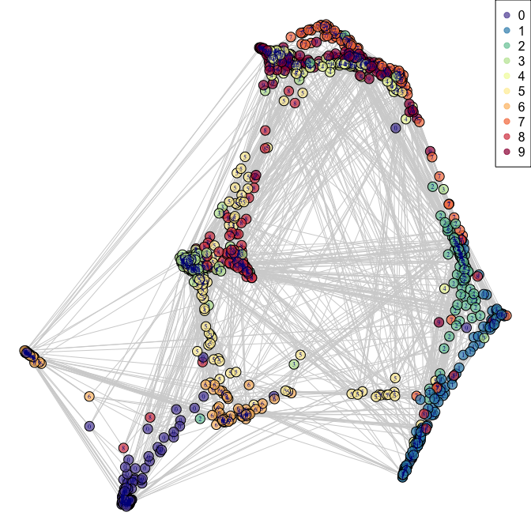

```
# 1. Finding an lcc...
# IGRAPH 5c02820 U--- 1000 5797 --
# + attr: color (v/c)
# 3. Embedding the graph into dmax = 20...
# 4. Finding an elbow (dimension reduction)..., use dhat =  10
# 5. Clustering vertices..., Khat =  10
# ----------------------------------------------------
# Gaussian finite mixture model fitted by EM algorithm
# ----------------------------------------------------
#
# Mclust VVV (ellipsoidal, varying volume, shape, and orientation) model with 10 components:
#
#  log.likelihood    n  df      BIC      ICL
#        27414.33 1000 659 50276.46 50252.37
#
# Clustering table:
#   1   2   3   4   5   6   7   8   9  10
# 164 100 103  75  84  81  88  98  83 124
```

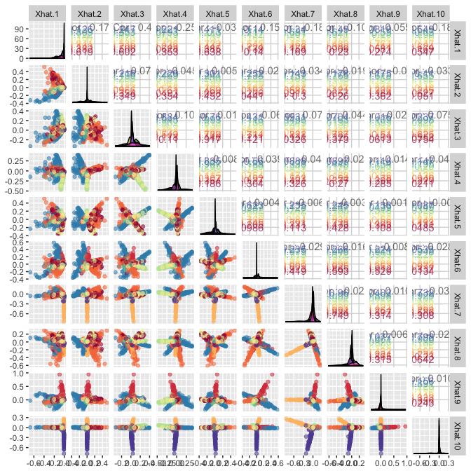

|  | 1 | 2 | 3 | 4 | 5 | 6 | 7 | 8 | 9 | 10 |
| --- | --- | --- | --- | --- | --- | --- | --- | --- | --- | --- |
| 0 | 0 | 0 | 6 | 74 | 0 | 0 | 19 | 0 | 0 | 0 |
| 1 | 105 | 0 | 0 | 0 | 0 | 0 | 0 | 0 | 0 | 0 |
| 2 | 24 | 0 | 5 | 0 | 5 | 20 | 4 | 1 | 0 | 46 |
| 3 | 3 | 0 | 0 | 0 | 11 | 5 | 21 | 75 | 0 | 2 |
| 4 | 3 | 9 | 1 | 0 | 1 | 32 | 0 | 0 | 39 | 12 |
| 5 | 10 | 1 | 2 | 0 | 1 | 8 | 31 | 19 | 0 | 4 |
| 6 | 4 | 0 | 87 | 0 | 0 | 0 | 2 | 0 | 0 | 0 |
| 7 | 7 | 53 | 0 | 0 | 0 | 1 | 0 | 0 | 2 | 39 |
| 8 | 5 | 2 | 0 | 1 | 66 | 3 | 9 | 3 | 0 | 1 |
| 9 | 3 | 35 | 2 | 0 | 0 | 12 | 2 | 0 | 42 | 20 |

```
# ARI for Khat = 10  is  0.42
```

```
#  0  1  2  3  4  5  6  7  8  9
#  4  1 10  8  9  7  3  2  5  9
```

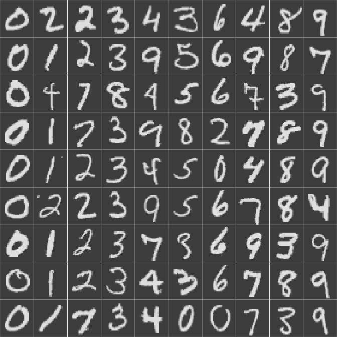

[^1]: D.L. Sussman, M. Tang, D.E. Fishkind, and C.E. Priebe, A consistent adjacency spectral embedding for stochastic blockmodel graphs, Journal of the American Statistical Association, Vol. 107, No. 499, pp. 1119-1128, 2012.
[^2]: M. Zhu, and A. Ghodsi, Automatic dimensionality selection from the scree plot via the use of profile likelihood. Computational Statistics and Data Analysis, Vol. 51, 918–930, 2006.
[^3]: MCLUST Version 4 for R: Normal Mixture Modeling for Model-Based Clustering, Classification, and Density Estimation, Technical Report no. 597, Department of Statistics, University of Washington, June 2012.
[^4]: K. Eichler, F. Li, A. L. Kumar, Y. Park, I. Andrade, C. Schneider-Mizell, T. Saumweber, A. Huser, D. Bonnery, B. Gerber, R. D. Fetter, J. W. Truman, C. E. Priebe, L. F. Abbott, A. Thum, M. Zlatic, and A. Cardona, “The complete connectome of a learning and memory center in an insect brain,” Nature, no. 548, pp. 175-182, 2017.
[^5]: http://yann.lecun.com/exdb/mnist/